# Deskriptivstatistik für Intervallskalen - Lösungen

2020-11-26

### Vorbereitung

**Lösung**

Laden Sie zunächst den Datensatz `fb20` von der pandar-Website.

```r
fb20 <- read.table('https://pandar.netlify.app/post/fb20.csv',
  header = TRUE,
  sep = ',',
  na.strings = '-99')
```

Die Bedeutung der einzelnen Variablen und ihre Antwortkategorien können Sie dem Dokument Variablenübersicht.docx entnehmen.

Verschaffen Sie sich nun einen Überblick über den Datensatz:

```r
dim(fb20)
```

```
## [1] 98 32
```

```r
str(fb20)
```

```
## 'data.frame':    98 obs. of  32 variables:
##  $ mdbf1  : int  3 5 4 4 5 4 3 4 2 4 ...
##  $ mdbf2  : int  2 3 4 2 4 4 4 2 2 2 ...
##  $ mdbf3  : int  4 2 2 3 2 1 1 4 4 2 ...
##  $ mdbf4  : int  3 1 1 NA 1 1 2 3 4 2 ...
##  $ mdbf5  : int  2 3 1 4 1 1 1 3 4 4 ...
##  $ mdbf6  : int  1 4 4 2 4 3 4 3 2 4 ...
##  $ mdbf7  : int  2 3 1 5 2 3 1 4 4 4 ...
##  $ mdbf8  : int  3 5 4 3 5 4 4 4 2 4 ...
##  $ mdbf9  : int  4 1 2 4 2 1 1 4 4 2 ...
##  $ mdbf10 : int  3 3 4 1 3 4 3 3 2 4 ...
##  $ mdbf11 : int  2 1 1 3 2 1 1 3 5 2 ...
##  $ mdbf12 : int  2 5 4 2 4 4 4 2 2 4 ...
##  $ lz     : num  5.4 6.8 5 3.6 5.6 5.4 4.8 3.6 5 5.4 ...
##  $ extra  : num  3.5 4 3.5 2.75 4.25 3 3.5 4 3.25 3.5 ...
```

[output cut: 18 more lines]

Der Datensatz besteht aus 98 Zeilen (Beobachtungen) und 32 Spalten (=Variablen).

## Aufgabe 1

Erstellen Sie im Datensatz `fb20` die Skalenwerte für wach vs. müde (wm) und ruhig vs. unruhig (ru). Diese Skalen umfassen die folgenden Items (negative Items sind unterstrichen):

- Wach vs. müde: ausgeruht (mdbf2), schlapp (mdbf5), müde (mdbf7), munter (mdbf10)
- Ruhig vs. unruhig: ruhelos (mdbf3), gelassen (mdbf6), unruhig (mdbf9), entspannt (mdbf12)

Erstellen Sie die Skalenwerte als Mittelwert der jeweiligen vier Items.

**Lösung**

**Für wach/müde Items**

```r
# Rekodierung
# Variante 1: lineare Transformation

fb20$mdbf5_r <- -1 * (fb20$mdbf5 - 6)
fb20$mdbf7_r <- -1 * (fb20$mdbf7 - 6)

# Skalenwert

wach <- fb20[, c('mdbf2', 'mdbf5_r', 'mdbf7_r', 'mdbf10')]
fb20$wm <- rowMeans(wach)
```

**Für ruhig/unruhig Items**

```r
# Rekodierung
# Variante 2: logische Filter

fb20$mdbf3_r[fb20$mdbf3 == 1] <- 5
fb20$mdbf3_r[fb20$mdbf3 == 2] <- 4
fb20$mdbf3_r[fb20$mdbf3 == 3] <- 3
fb20$mdbf3_r[fb20$mdbf3 == 4] <- 2
fb20$mdbf3_r[fb20$mdbf3 == 5] <- 1

fb20$mdbf9_r[fb20$mdbf9 == 1] <- 5
fb20$mdbf9_r[fb20$mdbf9 == 2] <- 4
fb20$mdbf9_r[fb20$mdbf9 == 3] <- 3
fb20$mdbf9_r[fb20$mdbf9 == 4] <- 2
fb20$mdbf9_r[fb20$mdbf9 == 5] <- 1

# Skalenwert

ruhig <- fb20[, c('mdbf3_r', 'mdbf6', 'mdbf9_r', 'mdbf12')]
fb20$ru <- rowMeans(ruhig)
```

## Aufgabe 2

Bestimmen Sie für beide Skalenwerte jeweils Mittelwert und Median.

- Was vermuten Sie, aufgrund des Verhältnisses der beiden Maße der zentralen Tendenz, bezüglich der Schiefe der Verteilungen?
- Prüfen Sie Ihre Vermutungen anhand von Histogrammen!

**Lösung**

```r
# Für wach/müde
median(fb20$wm, na.rm = TRUE)
```

```
## [1] 3.5
```

```r
mean(fb20$wm, na.rm = TRUE)
```

```
## [1] 3.313776
```

```r
# Für ruhig/unruhig
median(fb20$ru, na.rm = TRUE)
```

```
## [1] 3.5
```

```r
mean(fb20$ru, na.rm = TRUE)
```

```
## [1] 3.32398
```

**Prüfen der Vermutungen anhand von Histogrammen!**

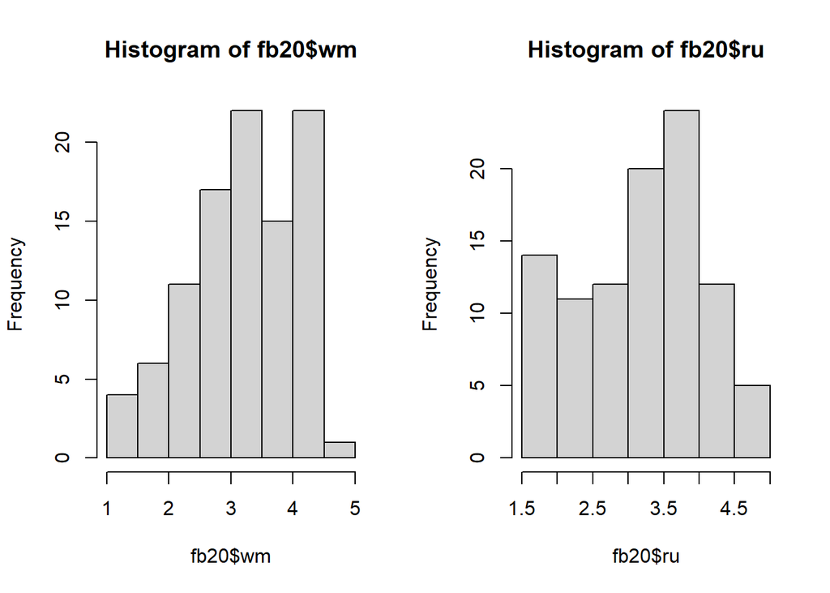

```r
# Histogramme (nebeneinander)
par(mfrow=c(1,2))
hist(fb20$wm)
hist(fb20$ru)
```

## Aufgabe 3

Bestimmen Sie für den Skalenwert `wm` die empirische Varianz.

- Ist diese größer oder kleiner als diejenige Schätzung, die mithilfe von `var(...)` bestimmt wird?
- Warum?

**Lösung**

**Erinnerung:**

- Empirische Varianz: $s^2_{X} = \frac{\sum_{m=1}^n (x_m - \bar{x})^2}{n}$
- Schätzer der Populationsvarianz: $\hat{\sigma}^2_{X} = \frac{\sum_{m=1}^n (x_m - \bar{x})^2}{n - 1}$

Zur Berechnung der Varianz gemäß Formel benötigen wir $n$. Wir könnten mit `nrow(fb20)` die Länge des Datensatzes für `n` heranziehen. Dies ist jedoch nur dann sinnvoll, wenn auf der Variable `wm` keine fehlenden Werte vorhanden sind!

```r
sum(is.na(fb20$wm))
```

```
## [1] 0
```

Hier gibt es tatäschlich keine fehlenden Werte, daher ist folgende Formel legitim:

```r
# empirische Varianz
# per Hand
sum((fb20$wm - mean(fb20$wm))^2) / nrow(fb20)
```

```
## [1] 0.7299888
```

```r
# durch Umrechnung
var(fb20$wm) * (nrow(fb20)-1) / nrow(fb20)
```

```
## [1] 0.7299888
```

```r
# Populationsschätzer
var(fb20$wm)
```

```
## [1] 0.7375145
```

Die empirische Varianz (0.73) ist kleiner als der Populationsschätzer (0.738), weil durch `n`, beim Populationsschätzer jeodoch durch `(n-1)` geteilt wird.

## Aufgabe 4

Erstellen Sie eine z-standardisierte Variante der wach vs. müde Skala als `wm_z`.

- Erstellen Sie für diese standardisierte Variable ein Histogramm.
- Was fällt Ihnen auf, wenn Sie dieses mit dem Histogramm der unstandardisierten Werte vergleichen?
- Erstellen Sie beide Histogramme noch einmal mit 20 Kategorien.

**Lösung**

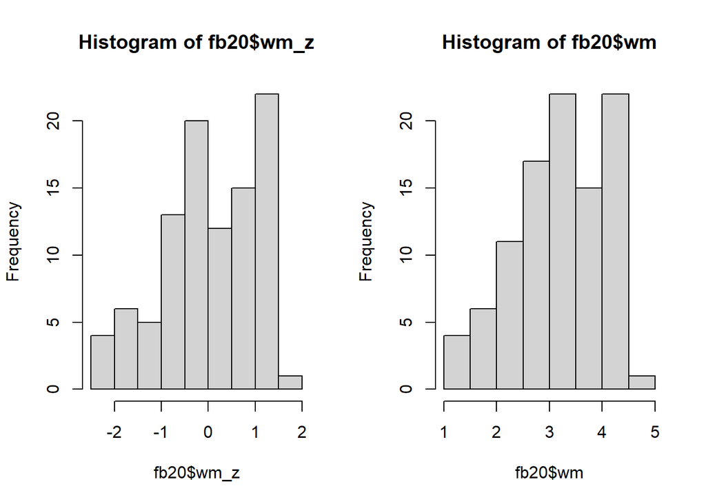

```r
par(mfrow=c(1,2))

# z-Standardisierung
fb20$wm_z <- scale(fb20$wm)

# Histogramme
hist(fb20$wm_z)
hist(fb20$wm)
```

Beim Vergleich der beiden Histogrammen fällt auf, dass sich - aufgrund der R-Voreinstellungen - das Erscheinungsbild fälschlicherweise unterscheidet - eigentlich sollte sich durch die z-Transformation nur Skalierung der x-Achsen-Variable verändern. Tatsächlich aber bestimmt R hier eine unterschiedliche Anzahl von Kategorien. Wir halten diese nun über das `breaks`-Argument konstant:

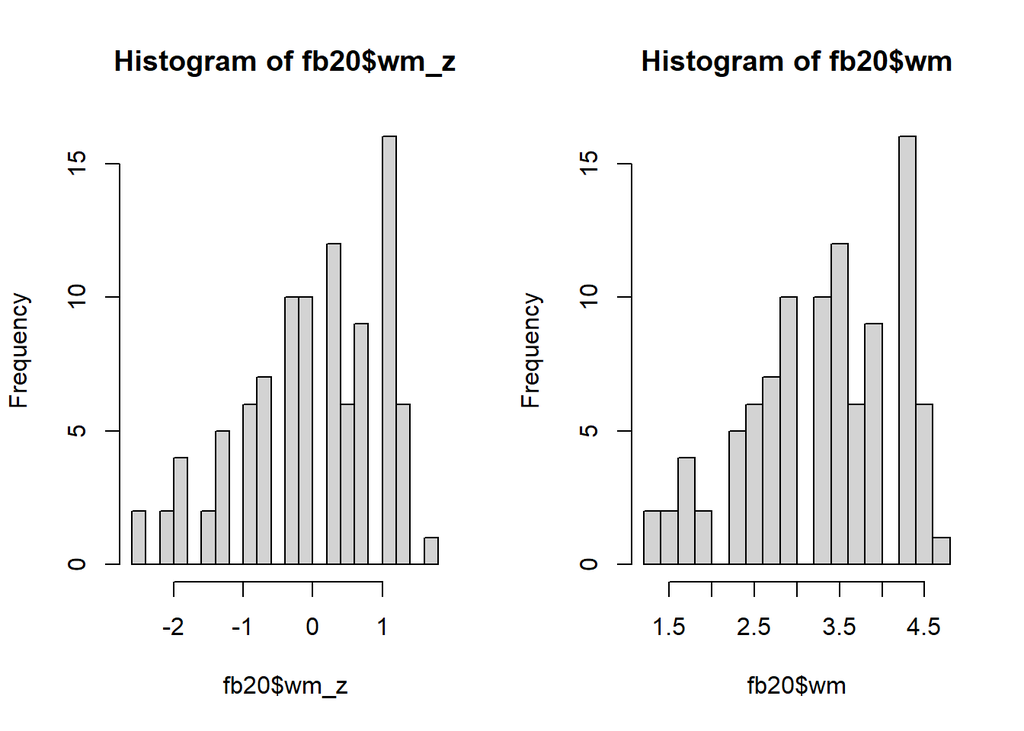

```r
# Histogramme mit jeweils 20 Kategorien
par(mfrow=c(1,2))
hist(fb20$wm_z, breaks = 20)
hist(fb20$wm, breaks = 20)
```

Die Verteilungen sehen nun tatächlich (fast) gleich aus.